# Wine dataset notebook

# Loading Wine datasets

```r
set.seed(42)
library(ggplot2)
library(reshape2)
library(plyr)
library(readr)
library(fpc)
library(data.table)
library(ggplot2)
```

## Datasets description

```
For more information, read [Cortez et al., 2009].
Input variables (based on physicochemical tests):

1 - fixed acidity        (FA)
2 - volatile acidity     (VA)
3 - citric acid          (CA)
4 - residual sugar       (RS)
5 - chlorides            (CH)
6 - free sulfur dioxide  (FSD)
7 - total sulfur dioxide (TSD)
8 - density              (DEN)
9 - pH                   (pH)
10 - sulphates           (SUL)
11 - alcohol             (ALC)

Output variable (based on sensory data):
12 - quality (score between 0 and 10) - (QLT)
```

Volatile acidity refers to the steam distillable acids present in wine, primarily acetic acid but also lactic, formic, butyric, and propionic acids. Commonly, these acids are measured by Cash Still, though now they can be measured by gas chromatography, HPLC or enzymatic methods.

Sulphur dioxide (SO2) is the most widely used and controversial additive in winemaking. Its main functions are to inhibit or kill unwanted yeasts and bacteria, and to protect wine from oxidation.

In wine tasting, the term “acidity” refers to the fresh, tart and sour attributes of the wine which are evaluated in relation to how well the acidity balances out the sweetness and bitter components of the wine such as tannins. Three primary acids are found in wine grapes: tartaric, malic and citric acids

Sulfates aren’t involved in wine production, but some beer makers use calcium sulfate—also known as brewers’ gypsum—to correct mineral deficiencies in water during the brewing process. Sulfites are naturally occurring compounds found in all wines; they act as a preservative by inhibiting microbial growth.

Red wines from different countries have been assessed in order to determine the influence of terroir and grape variety in their concentration of chloride. [Ref](http://www.scielo.br/scielo.php?script=sci_arttext&pid=S0101-20612015000100095)

## Reading red wines dataset

```r
wines_red_data <-
  read.csv(
    "http://archive.ics.uci.edu/ml/machine-learning-databases/wine-quality/winequality-red.csv",
    sep=";",
    header = TRUE,
    col.names = c("FA","VA","CA","RS","CH","FSD","TSD","DEN","pH","SUL","ALC","QLT"))
wines_red_data$TYPE <- 0
```

## Reading white wines dataset

```r
wines_white_data <-
  read.csv(
    "http://archive.ics.uci.edu/ml/machine-learning-databases/wine-quality/winequality-white.csv",
    sep=";",
    header = TRUE,
    col.names = c("FA","VA","CA","RS","CH","FSD","TSD","DEN","pH","SUL","ALC","QLT"))
wines_white_data$TYPE <- 1
```

## Combining the datasets

```r
wines_data <- rbind(wines_red_data, wines_white_data)
summary(wines_data)
```

```
       FA               VA               CA               RS               CH               FSD              TSD             DEN
 Min.   : 3.800   Min.   :0.0800   Min.   :0.0000   Min.   : 0.600   Min.   :0.00900   Min.   :  1.00   Min.   :  6.0   Min.   :0.9871
 1st Qu.: 6.400   1st Qu.:0.2300   1st Qu.:0.2500   1st Qu.: 1.800   1st Qu.:0.03800   1st Qu.: 17.00   1st Qu.: 77.0   1st Qu.:0.9923
 Median : 7.000   Median :0.2900   Median :0.3100   Median : 3.000   Median :0.04700   Median : 29.00   Median :118.0   Median :0.9949
 Mean   : 7.215   Mean   :0.3397   Mean   :0.3186   Mean   : 5.443   Mean   :0.05603   Mean   : 30.53   Mean   :115.7   Mean   :0.9947
 3rd Qu.: 7.700   3rd Qu.:0.4000   3rd Qu.:0.3900   3rd Qu.: 8.100   3rd Qu.:0.06500   3rd Qu.: 41.00   3rd Qu.:156.0   3rd Qu.:0.9970
 Max.   :15.900   Max.   :1.5800   Max.   :1.6600   Max.   :65.800   Max.   :0.61100   Max.   :289.00   Max.   :440.0   Max.   :1.0390
       pH             SUL              ALC             QLT             TYPE
 Min.   :2.720   Min.   :0.2200   Min.   : 8.00   Min.   :3.000   Min.   :0.0000
 1st Qu.:3.110   1st Qu.:0.4300   1st Qu.: 9.50   1st Qu.:5.000   1st Qu.:1.0000
 Median :3.210   Median :0.5100   Median :10.30   Median :6.000   Median :1.0000
 Mean   :3.219   Mean   :0.5313   Mean   :10.49   Mean   :5.818   Mean   :0.7539
 3rd Qu.:3.320   3rd Qu.:0.6000   3rd Qu.:11.30   3rd Qu.:6.000   3rd Qu.:1.0000
 Max.   :4.010   Max.   :2.0000   Max.   :14.90   Max.   :9.000   Max.   :1.0000
```

# Clustering

## Wines dataset normalizing

```r
wines_data.std <- scale(wines_data[1:11])
head(wines_data.std)
```

```
            FA         VA        CA         RS        CH        FSD        TSD       DEN         pH       SUL        ALC
[1,] 0.1424623  2.1886645 -2.192664 -0.7447208 0.5699140 -1.1000552 -1.4462472 1.0349132  1.8129500 0.1930819 -0.9153937
[2,] 0.4510010  3.2819823 -2.192664 -0.5975941 1.1978825 -0.3112961 -0.8624022 0.7014323 -0.1150642 0.9995017 -0.5800235
[3,] 0.4510010  2.5531038 -1.917405 -0.6606484 1.0266184 -0.8746955 -1.0924018 0.7681285  0.2580999 0.7978967 -0.5800235
[4,] 3.0735801 -0.3624106  1.660957 -0.7447208 0.5413699 -0.7620156 -0.9862481 1.1016093 -0.3638402 0.3274852 -0.5800235
[5,] 0.1424623  2.1886645 -2.192664 -0.7447208 0.5699140 -1.1000552 -1.4462472 1.0349132  1.8129500 0.1930819 -0.9153937
[6,] 0.1424623  1.9457049 -2.192664 -0.7657389 0.5413699 -0.9873753 -1.3400936 1.0349132  1.8129500 0.1930819 -0.9153937
```

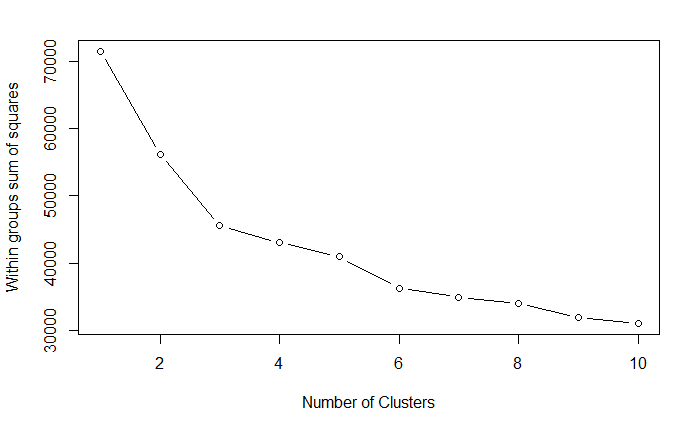

```r
#A fundamental question is how to determine the value of the parameter k.
#If we looks at the percentage of variance explained as a function of the number of clusters:
#One should choose a number of clusters so that adding another cluster doesnât give much better
#modeling of the data. More precisely, if one plots the percentage of variance explained by the
#clusters against the number of clusters, the first clusters will add much information
#(explain a lot of variance), but at some point the marginal gain will drop,
#giving an angle in the graph. The number of clusters is chosen at this point, hence the âelbow criterionâ.
wssplot <- function(data, nc=15, seed=1234){
  wss <- (nrow(data)-1)*sum(apply(data,2,var))
  for (i in 2:nc){
    set.seed(seed)
    wss[i] <- sum(kmeans(data, centers=i)$withinss)}
  plot(1:nc, wss, type="b", xlab="Number of Clusters",
       ylab="Within groups sum of squares")}
wssplot(wines_data.std, nc=10)
```

```r
clusters_num = 3
k.means.fit <- kmeans(wines_data.std, clusters_num,iter.max = 1000)
# attributes(k.means.fit)
k.means.fit$centers
```

```
          FA         VA           CA         RS          CH         FSD         TSD        DEN          pH        SUL        ALC
1 -0.1839863 -0.3534198  0.279108125  1.1998473 -0.08840616  0.84685371  0.95753497  0.7580959 -0.38773319 -0.2580380 -0.7954480
2 -0.3493514 -0.4029846 -0.005436896 -0.4362877 -0.44308115 -0.09101054  0.03476467 -0.8518159 -0.03960046 -0.2833150  0.5690282
3  0.8787523  1.1816140 -0.321751587 -0.6032147  0.94209722 -0.83549093 -1.20473049  0.7071704  0.53604029  0.8421072 -0.1285825
```

```r
# plot(k.means.fit$centers[,c("RS","ALC")])
# k.means.fit$cluster
k.means.fit$size
```

```
[1] 1895 3009 1593
```

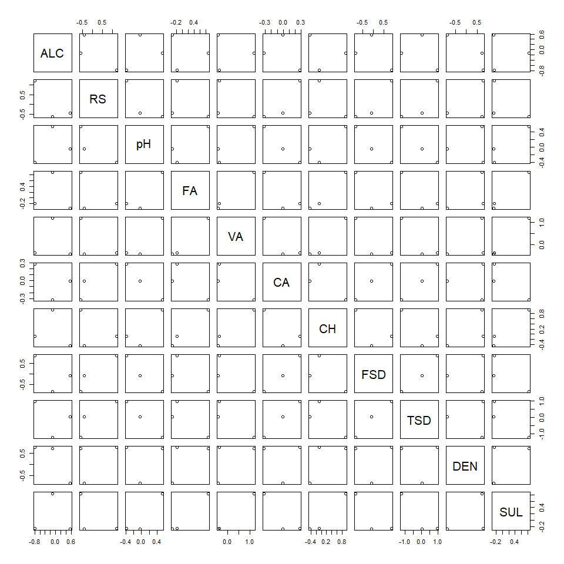

```r
pairs(~ALC+RS+pH+FA+VA+CA+CH+FSD+TSD+DEN+SUL, data=k.means.fit$centers)
```

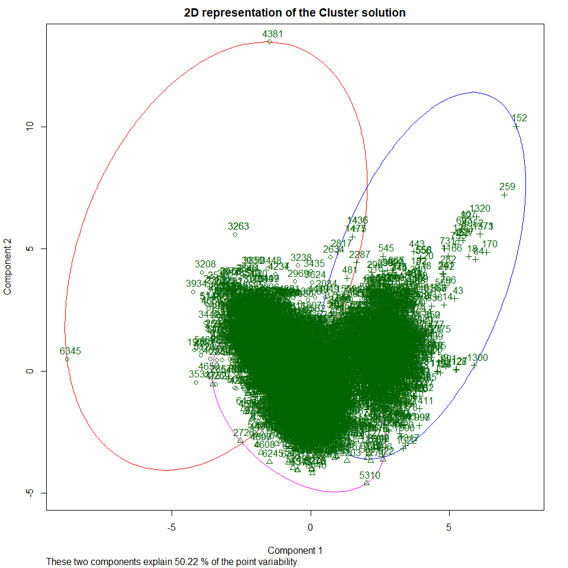

```r
library(cluster)
clusplot(wines_data.std, k.means.fit$cluster, main='2D representation of the Cluster solution',
         color=TRUE, shade=FALSE,
         labels=clusters_num, lines=0)
```

## In order to evaluate the clustering performance we build a confusion matrix:

```r
table(wines_data[,13],k.means.fit$cluster)
```

```
       1    2    3
  0    4   57 1538
  1 1891 2952   55
```

```r
table(wines_data[,12],k.means.fit$cluster)
```

```
       1    2    3
  3   12    8   10
  4   48  100   68
  5  804  638  696
  6  843 1371  622
  7  157  740  182
  8   30  148   15
  9    1    4    0
```